# What is the functional response of a recreational hunter?

Drew Tyre

2019-04-12

A few years ago I built a white-tailed deer population model to evaluate different harvest strategies. 2 sexes, density dependence, age structure, it was fun. The main problem I came across was figuring out how changes in population size and structure would interact with management to change harvest mortality. In consumer-resource modeling terminology, I didn’t know what the functional response of hunters was. So here’s my first shot at it.

To keep things simple, I will just think about 2 types of deer, does ($N_d$) and bucks ($N_b$). Furthermore, hunters always prefer bucks. In practice this means if they encounter a buck they harvest it. The real trick is figuring out what they do when they encounter a doe. Simplifying again, each permit only allows 1 deer, so if they take a doe then that precludes taking a buck. Each hunter has some limited time in which to harvest any animal (limited season). Simplifying, assume that’s the same for all hunters. Finally, hunters encounter deer at rates proportional to their abundance $\lambda(N)$. This rate depends on deer behavior, hunter behavior, and the habitat involved.

If hunters have discrete intervals in which to encounter a deer, then this is kind of like a negative binomial distribution – how many non-bucks are encountered before encountering a buck. The problem is we have two kinds of events, not one. For a single interval

$$p(buck | N) = 1-e^{\lambda N_b} \\
p(doe | N) = (1-e^{\lambda N_d})(1-p(buck)) \\
p(nothing) = (1 - p(buck))(1-p(doe))$$

Here I assume that if a doe and a buck are encountered, the hunter always takes the buck and ignores the doe. Also, if more than one buck or doe is encountered that’s the same as encountering one.

So this is a dynamic programming problem – there are T intervals, and on each interval the decision is to take a doe or not.

$$V(t) = max(p(buck) + v_d p(doe) + V(t+1) p(nothing), \\
p(buck) + V(t+1)(p(doe) + p(nothing)))$$

where $0 \leq v_d \leq 1$ is the relative value of a doe compared to a buck.

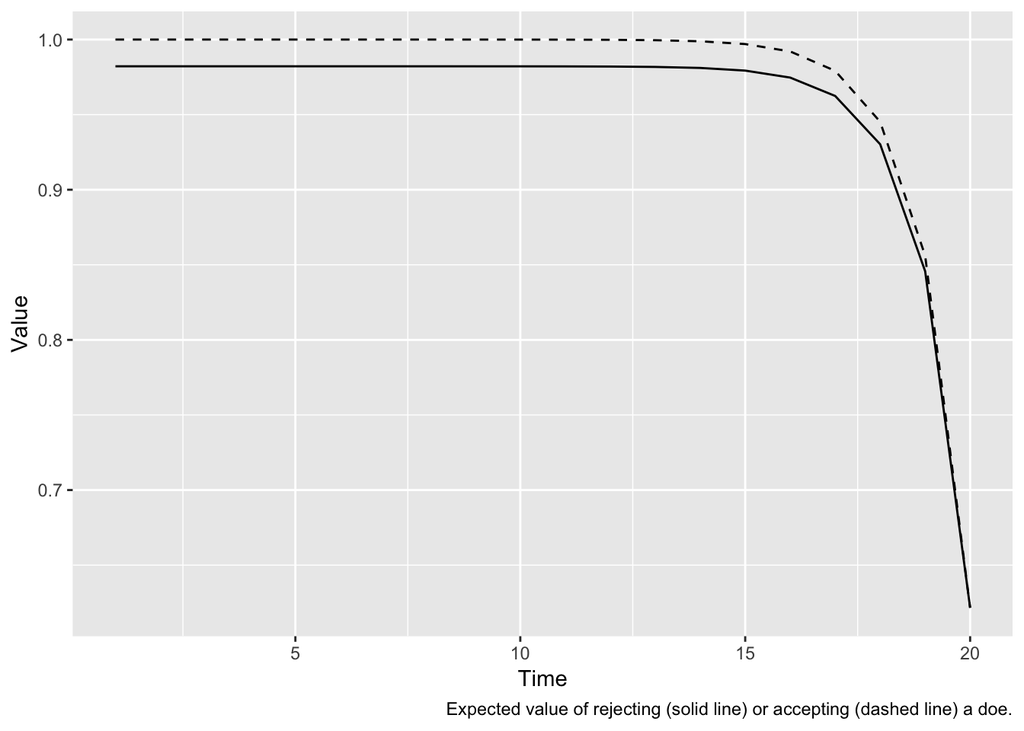